# Practical Machine Learning Final Project

2016, 25 November

# Introduction

The introduction of technologies of the Internet of Things has made possible the collection of a huge amount of data related to personal activities in an inexpensive way. People regularly quantify how much of an activity they are doing, but they don’t pay as much attention to the quality of the exercise. The given data set consist of data from the sensors in the forearm, arm, belt and dumbbell collected from 6 participants who has been asked to perform barbell lifts correctly and incorrectly in 5 different ways. The goal is being able to predict, given a new reading of the sensors, if the actual exercise has been performed correctly, as indicated in the “classe” variable of the data set. Finally to check accuracy of the prediction algorithm, it will be applied to a testing set.

## Data

Both the training data nad the test data are available in the from http://groupware.les.inf.puc-rio.br/har in the following url:

1.Training set: https://d396qusza40orc.cloudfront.net/predmachlearn/pml-training.csv

2.Testing set: https://d396qusza40orc.cloudfront.net/predmachlearn/pml-testing.csv

# Getting, Loading and cleaning the data

Loading the required libraries for the analysis:

```r
library(rpart.plot)
library(caret)
library(rpart)
library(RColorBrewer)
library(rattle)
library(randomForest)
library(knitr)
```

The data should be loaded and cleaned. As a fist step we load the data into two datasets, training and testing. We remove the colums with missing values and remove the columns from 1 to 7 as they have no predicting value:

```r
##Reading the data and deleting the columns with no valid
trainingDataSet <- read.csv(url("http://d396qusza40orc.cloudfront.net/predmachlearn/pml-training.csv"), na.strings=c("NA","#DIV/0!",""))
testingDataSet <- read.csv(url("http://d396qusza40orc.cloudfront.net/predmachlearn/pml-testing.csv"), na.strings=c("NA","#DIV/0!",""))

##Removing NA values
trainingDataSet <- trainingDataSet[, colSums(is.na(trainingDataSet)) == 0]
testingDataSet  <- testingDataSet[, colSums(is.na(testingDataSet)) == 0]

##Removing columns from 1 to 7
trainingDataSet <- trainingDataSet[, -c(1:7)]
testingDataSet <- testingDataSet[, -c(1:7)]
```

Double check if there are near zero variance variables to remove them from the dataset. All the remaining variables are not near zero variables as shown adding up the nz boolean column of the nearZeroVar data resulting of the analysis.

```r
nzvalues <- nearZeroVar(trainingDataSet, saveMetrics=TRUE)
#The colum nz that shows if a varible is "near zero" are all FALSE
sum(nzvalues$nzv)
```

```
FALSE [1] 0
```

Once loaded and cleaning the data. It’s required to partition the training set into a dataset to train the model and another partition to make the validations. The training data set covers 70% of the original training set, while the other 30% belongs to the validation set. The final test will be done in the testing dataset (testingDataSet)

```r
trainingList <- createDataPartition(trainingDataSet$classe, p = 0.7, list = FALSE)
trainingModelDataSet  <- trainingDataSet[trainingList, ]
validationModelDataSet <- trainingDataSet[-trainingList, ]
```

# Predictions models

## Predictions with decision trees

We use cross-validation with k-fold with K=5 to save some computing time. Although we consider minor effects, we experiment with preprocessing the data:

```r
fitmodelDecTrees <- train(classe ~ ., data = trainingModelDataSet, method = "rpart",
                   preProcess=c("center", "scale"),trControl = trainControl(method ="cv", number = 5))
#Show a picture of the model
print(fitmodelDecTrees)
```

```
CART

13737 samples
   52 predictor
    5 classes: 'A', 'B', 'C', 'D', 'E'

Pre-processing: centered (52), scaled (52)
Resampling: Cross-Validated (5 fold)
Summary of sample sizes: 10989, 10990, 10990, 10989, 10990
Resampling results across tuning parameters:

  cp         Accuracy   Kappa
  0.0368223  0.5124109  0.36313763
  0.0597769  0.4685939  0.29620122
  0.1162649  0.3329705  0.07401664

Accuracy was used to select the optimal model using  the largest value.
The final value used for the model was cp = 0.0368223.
```

A representation of the decision tree:

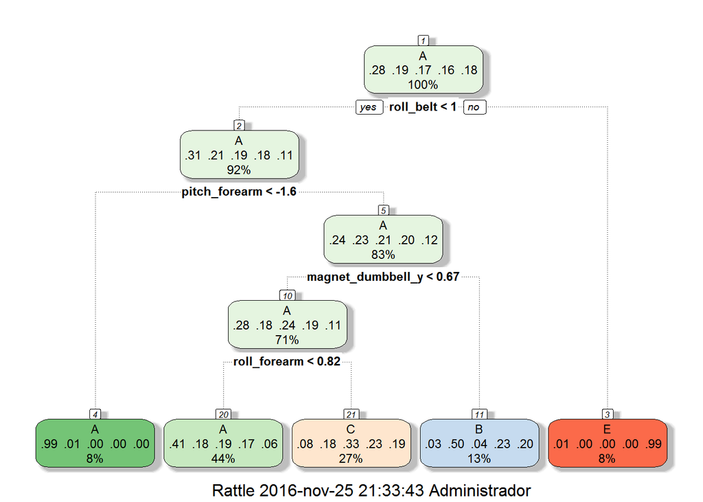

```r
fancyRpartPlot(fitmodelDecTrees$finalModel)
```

Calculate the confusion matrix and the accuracy of the adjusted model:

```r
prWithDecsTrees<- predict(fitmodelDecTrees, validationModelDataSet)
cmatrixDecstree <- confusionMatrix(prWithDecsTrees,validationModelDataSet$classe)
print(cmatrixDecstree)
```

```
Confusion Matrix and Statistics

          Reference
Prediction    A    B    C    D    E
         A 1514  451  462  435  182
         B   24  394   39  166  137
         C  133  294  525  363  286
         D    0    0    0    0    0
         E    3    0    0    0  477

Overall Statistics

               Accuracy : 0.4945
                 95% CI : (0.4816, 0.5073)
    No Information Rate : 0.2845
    P-Value [Acc > NIR] : < 2.2e-16

                  Kappa : 0.3396
 Mcnemar's Test P-Value : NA

Statistics by Class:

                     Class: A Class: B Class: C Class: D Class: E
Sensitivity            0.9044  0.34592  0.51170   0.0000  0.44085
Specificity            0.6367  0.92288  0.77856   1.0000  0.99938
Pos Pred Value         0.4974  0.51842  0.32792      NaN  0.99375
Neg Pred Value         0.9437  0.85463  0.88305   0.8362  0.88807
Prevalence             0.2845  0.19354  0.17434   0.1638  0.18386
Detection Rate         0.2573  0.06695  0.08921   0.0000  0.08105
Detection Prevalence   0.5172  0.12914  0.27205   0.0000  0.08156
Balanced Accuracy      0.7705  0.63440  0.64513   0.5000  0.72011
```

The accuracy:

```r
#Accuracy
cmatrixDecstree$overall[1]
```

```
##  Accuracy
## 0.4944775
```

The accuracy is very low, It does not achieve even the 50% chance. As a conclusion we try with different approaches to compare and search for better results.

## Predictions with random forest

We fit other model using random forest:

```r
fitmodelRandomforest <- train(classe ~ ., data = trainingModelDataSet, method = "rf",
                   preProcess=c("center", "scale"),trControl = trainControl(method ="cv", number =5))

#printing the model
print(fitmodelRandomforest, digits = 4)
```

```
Random Forest

13737 samples
   52 predictor
    5 classes: 'A', 'B', 'C', 'D', 'E'

Pre-processing: centered (52), scaled (52)
Resampling: Cross-Validated (5 fold)
Summary of sample sizes: 10989, 10991, 10989, 10989, 10990
Resampling results across tuning parameters:

  mtry  Accuracy  Kappa
   2    0.9921    0.9901
  27    0.9912    0.9889
  52    0.9854    0.9816

Accuracy was used to select the optimal model using  the largest value.
The final value used for the model was mtry = 2.
```

Plotting

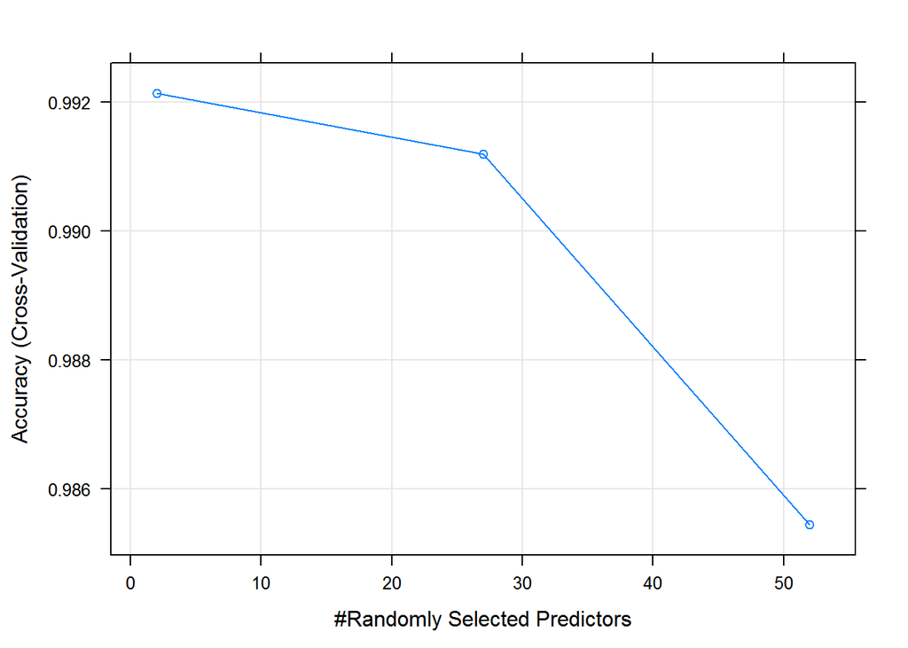

```r
#Ploting the model
plot(fitmodelRandomforest)
```

Use the model to calculate the confusion matrix using the validation dataset:

```r
prWithRandomForest<- predict(fitmodelRandomforest, validationModelDataSet)
cmatrixRandomForest <- confusionMatrix(prWithRandomForest, validationModelDataSet$classe)
print(cmatrixRandomForest)
```

```
Confusion Matrix and Statistics

          Reference
Prediction    A    B    C    D    E
         A 1672   11    0    0    0
         B    2 1125   11    0    0
         C    0    3 1013   24    0
         D    0    0    2  940    4
         E    0    0    0    0 1078

Overall Statistics

               Accuracy : 0.9903
                 95% CI : (0.9875, 0.9927)
    No Information Rate : 0.2845
    P-Value [Acc > NIR] : < 2.2e-16

                  Kappa : 0.9877
 Mcnemar's Test P-Value : NA

Statistics by Class:

                     Class: A Class: B Class: C Class: D Class: E
Sensitivity            0.9988   0.9877   0.9873   0.9751   0.9963
Specificity            0.9974   0.9973   0.9944   0.9988   1.0000
Pos Pred Value         0.9935   0.9886   0.9740   0.9937   1.0000
Neg Pred Value         0.9995   0.9971   0.9973   0.9951   0.9992
Prevalence             0.2845   0.1935   0.1743   0.1638   0.1839
Detection Rate         0.2841   0.1912   0.1721   0.1597   0.1832
Detection Prevalence   0.2860   0.1934   0.1767   0.1607   0.1832
Balanced Accuracy      0.9981   0.9925   0.9909   0.9869   0.9982
```

The accuracy:

```r
#Accuracy
cmatrixRandomForest$overall[1]
```

```
 Accuracy
0.9903144
```

the accuracy is 0.991. Much better than the previous result, although the solution may be difficult to interpret.An estimation of the out of sample error is 1-0.9903=0,009.

## Prediction with Generalized Boosted Regresion

Drawing the model:

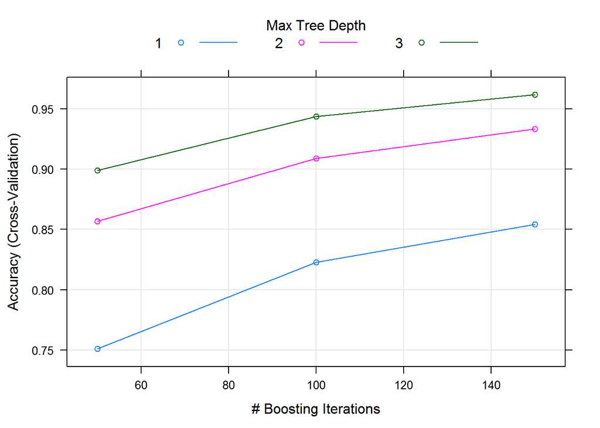

```r
#Plot of the model
plot(fitmodelGbm)
```

Use the validation dataset to calculate the accuracy of the model:

```r
prWithGbm <- predict(fitmodelGbm,validationModelDataSet)
cmatrixGbm <- confusionMatrix(prWithGbm, validationModelDataSet$classe)
print(cmatrixGbm)
```

```
Confusion Matrix and Statistics

          Reference
Prediction    A    B    C    D    E
         A 1648   39    0    3    1
         B   19 1074   43    2    8
         C    2   26  968   29   10
         D    2    0   14  924   17
         E    3    0    1    6 1046

Overall Statistics

               Accuracy : 0.9618
                 95% CI : (0.9565, 0.9665)
    No Information Rate : 0.2845
    P-Value [Acc > NIR] : < 2.2e-16

                  Kappa : 0.9516
 Mcnemar's Test P-Value : 7.075e-06

Statistics by Class:

                     Class: A Class: B Class: C Class: D Class: E
Sensitivity            0.9845   0.9429   0.9435   0.9585   0.9667
Specificity            0.9898   0.9848   0.9862   0.9933   0.9979
Pos Pred Value         0.9746   0.9372   0.9353   0.9655   0.9905
Neg Pred Value         0.9938   0.9863   0.9880   0.9919   0.9925
Prevalence             0.2845   0.1935   0.1743   0.1638   0.1839
Detection Rate         0.2800   0.1825   0.1645   0.1570   0.1777
Detection Prevalence   0.2873   0.1947   0.1759   0.1626   0.1794
Balanced Accuracy      0.9871   0.9639   0.9648   0.9759   0.9823
```

Accuracy:

```r
#Accuracy
cmatrixGbm$overall[1]
```

```
 Accuracy
0.9617672
```

The accuracy is less than the one of the random forest. An estimation of the out of sample error is 1-0.961=0,039.Much better than with decision trees but less accurate than the random forest approach.

# Predicting Results on the test data

Due to its best results we use random forest to predict the predicting results in the test data

```r
predict(fitmodelRandomforest, testingDataSet)
```

```
 [1] B A B A A E D B A A B C B A E E A B B B
Levels: A B C D E
```